# P3 Assessment - Solution

WXXXX KXXX AXXXXXXX

2024-08-17

## Task1 - Solution

In task one, although all the data-sets were already existed in the `01_rawdata`, and the [LINK](https://data.unicef.org/resources/data_explorer/unicef_f/?ag=UNICEF&df=GLOBAL_DATAFLOW&ver=1.0&dq=.MNCH_ANC4+MNCH_SAB.&startPeriod=2018&endPeriod=2022) was also provided for the external data-set. Normally the data can be pulled from webpages and URLs with simple `R Script` or HTTP requests. However, in this case I browsed the URL in a browser and downloaded the data in an Excel file (from the download option on the page) and I also added the Excel file in the `01_rawdata` folder. The reason was that reading data from a URL which loads data dynamically using JavaScript/AJAX, that needed some advanced techniques and some libraries that needed to be compiled locally e.g., `RSelenium` and some others, and I thought that might not be needed for this exercise. In a real word, this data can be extracted from the Indicator Data Warehouse (SDMX).

### Step1:

Load, clean and transform the Data downloaded from the DATA.UNICEF.ORG Website (Provided URL)  
Here’s a sample of the data:

| Country | Indicator | Gender | 2022 | 2021 | 2020 | 2019 | 2018 | Latest_Value |
| --- | --- | --- | --- | --- | --- | --- | --- | --- |
| Afghanistan | Antenatal care 4+ visits - percentage of women (aged 15-49 years) attended at least four times during pregnancy by any provider | Female | NA | NA | 27.6 | NA | 20.9 | 27.6 |
| Afghanistan | Skilled birth attendant - percentage of deliveries attended by skilled health personnel | Female | NA | NA | 61.8 | NA | 58.8 | 61.8 |
| Africa | Antenatal care 4+ visits - percentage of women (aged 15-49 years) attended at least four times during pregnancy by any provider | Female | 56.8 | NA | NA | NA | NA | 56.8 |
| Africa | Skilled birth attendant - percentage of deliveries attended by skilled health personnel | Female | 71 | NA | NA | NA | NA | 71 |
| Albania | Antenatal care 4+ visits - percentage of women (aged 15-49 years) attended at least four times during pregnancy by any provider | Female | NA | NA | NA | NA | 77.8 | 77.8 |

### Step 2:

Load the SDG Status Analysis of Under5 Mortality Target by Countries, clean and transform as needed and merge it with the `ANC & SUB Indicators Data`, prepared above.  
Here’s a sample of the loaded data:

| ISO3Code | OfficialName | Status.U5MR |
| --- | --- | --- |
| AFG | Afghanistan | Acceleration Needed |
| AGO | Angola | Acceleration Needed |
| AIA | Anguilla | Achieved |
| ALB | Albania | Achieved |
| AND | Andorra | Achieved |
| ARE | United Arab Emirates | Achieved |

Below is a sample of the merged data:

| Country | Indicator | Gender | 2022 | 2021 | 2020 | 2019 | 2018 | Latest_Value | ISO3Code | Status.U5MR |
| --- | --- | --- | --- | --- | --- | --- | --- | --- | --- | --- |
| Afghanistan | Antenatal care 4+ visits - percentage of women (aged 15-49 years) attended at least four times during pregnancy by any provider | Female | NA | NA | 27.6 | NA | 20.9 | 27.6 | AFG | Acceleration Needed |
| Afghanistan | Skilled birth attendant - percentage of deliveries attended by skilled health personnel | Female | NA | NA | 61.8 | NA | 58.8 | 61.8 | AFG | Acceleration Needed |
| Africa | Antenatal care 4+ visits - percentage of women (aged 15-49 years) attended at least four times during pregnancy by any provider | Female | 56.8 | NA | NA | NA | NA | 56.8 | NA | NA |
| Africa | Skilled birth attendant - percentage of deliveries attended by skilled health personnel | Female | 71 | NA | NA | NA | NA | 71 | NA | NA |
| Albania | Antenatal care 4+ visits - percentage of women (aged 15-49 years) attended at least four times during pregnancy by any provider | Female | NA | NA | NA | NA | 77.8 | 77.8 | ALB | Achieved |

### Step 3:

Load the Demographic Data - which has the Birth Rate Projection, there are two sheets in that Excel Workbook, the Projections sheet will be loaded as it has the Birth Rate Projection. Some transformation and filtering (to filter only 2022 projection) is also performed and it is merged with the data prepared above. In this step a sample of data is not shown because the data-set have many columns.

### Final Step:

As the data is ready, in this step Weighted Coverage will be calculated as per the provided formula. The `group_by` and `summarise` functions were used for this purpose, including SUM, Multiplication and Division. As instructed,only the calculation for Countries is needed, therefore the other type of locations are filtered out, also the data has been prepared for the calculation (e.g., changing the datatypes of the columns, etc.). The long indicators names were also replaced by shorter names, to look better on the visualization/chart.

Here’s the result for the Weighted Coverage for both indicators by SDG U5MR Status:

| Indicator | SDG_Status_U5MR | Weighted_Coverage |
| --- | --- | --- |
| Antenatal care 4+ visits (ANC4) | Off Track | 54.43187 |
| Antenatal care 4+ visits (ANC4) | On Track | 72.49865 |
| Skilled birth attendant (SAB) | Off Track | 63.75380 |
| Skilled birth attendant (SAB) | On Track | 91.74606 |

As now the data is ready visualization, I will simply plot it. I used Bar-Chart for this purpose - which is the best for comparing data side by side (On/Off countries).

Here’s the required visualization (Bar Chart)

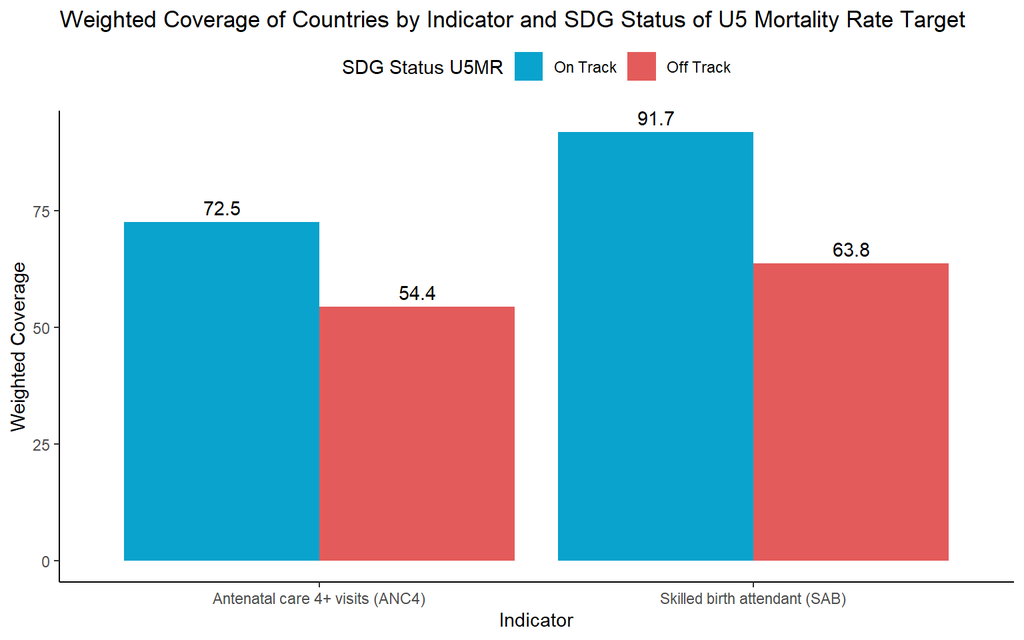

## Task 2 - Solution (Data Perspective)

As required for this task, the MICS Survey data is loaded, transformed and evaluated. As a first step, the data has been loaded, making sure that all variables (columns) in the data-set has correct data-types, and then some basic summary analysis of the data-set has been performed, before analyzing the key aspects (areas) as requested.

```
 interview_date     child_age_years child_birthday          EC6
 Length:2517        Min.   :3.000   Length:2517        Min.   :1.000
 Class :character   1st Qu.:3.000   Class :character   1st Qu.:2.000
 Mode  :character   Median :4.000   Mode  :character   Median :2.000
                    Mean   :3.514                      Mean   :1.906
                    3rd Qu.:4.000                      3rd Qu.:2.000
                    Max.   :4.000                      Max.   :9.000
      EC7             EC8             EC9             EC10
 Min.   :1.000   Min.   :1.000   Min.   :1.000   Min.   :1.000
 1st Qu.:2.000   1st Qu.:2.000   1st Qu.:1.000   1st Qu.:1.000
 Median :2.000   Median :2.000   Median :1.000   Median :2.000
 Mean   :1.899   Mean   :1.823   Mean   :1.165   Mean   :1.616
 3rd Qu.:2.000   3rd Qu.:2.000   3rd Qu.:1.000   3rd Qu.:2.000
 Max.   :9.000   Max.   :9.000   Max.   :9.000   Max.   :9.000
      EC11            EC12            EC13            EC14
 Min.   :1.000   Min.   :1.000   Min.   :1.000   Min.   :1.000
 1st Qu.:1.000   1st Qu.:1.000   1st Qu.:1.000   1st Qu.:1.000
 Median :1.000   Median :1.000   Median :1.000   Median :2.000
 Mean   :1.137   Mean   :1.266   Mean   :1.042   Mean   :1.521
 3rd Qu.:1.000   3rd Qu.:2.000   3rd Qu.:1.000   3rd Qu.:2.000
 Max.   :9.000   Max.   :9.000   Max.   :9.000   Max.   :9.000
      EC15
 Min.   :1.000
 1st Qu.:1.000
 Median :2.000
 Mean   :1.639
 3rd Qu.:2.000
 Max.   :9.000
```

From the Summary Analysis above, it’s clear that some variables data types are incorrect (interview_data, child_birthday), since one of the requirement of this task is to analyze the areas of interest in consideration of time (time series analysis) and for that it’s needed to keep the data in the correct format. Secondly, the categories will also be replaced with their textual representation, so the data can be more readable. A new variable is added to the data-set (month) in `2018-12` format, that’s extracted from the interview data. For this analysis, it’s assumed that repeated interviews were taken in the same locations in different months, to observe children growth.

| interview_date | child_age_years | child_birthday | EC6 | EC7 | EC8 | EC9 | EC10 | EC11 | EC12 | EC13 | EC14 | EC15 | month |
| --- | --- | --- | --- | --- | --- | --- | --- | --- | --- | --- | --- | --- | --- |
| 2019-03-31 | 3 | 2016-02-20 | No | No | Yes | Yes | No | Yes | Yes | Yes | No | No | 2019-03 |
| 2019-03-14 | 3 | 2015-10-19 | No | No | No | Yes | No | No | No | Yes | Yes | Yes | 2019-03 |
| 2019-03-17 | 4 | 2014-10-26 | No | No | No | Yes | Yes | Yes | No | Yes | No | Yes | 2019-03 |
| 2019-03-14 | 3 | 2015-03-21 | Yes | No | No | Yes | No | Yes | Yes | Yes | No | Yes | 2019-03 |
| 2019-03-14 | 3 | 2015-05-18 | No | Yes | Yes | Yes | No | Yes | No | Yes | No | Yes | 2019-03 |

### Methodology

For the analysis of the data, a form of time-series analysis method is used, because the indicators (children growth in specified areas) need to be looked up month by month. As mentioned above, the interview date will be considered as a date variable (in our case month) and based on that the other variables (indicators) will be analyzed. Trend charts (stacked bar) are created for the specified educational areas, and the responses (categories of responses) will be used to evaluate the distribution of response (by category) in each month. Proportion for each category of the responses are highlighted.

### Learning and Simple Math Skills:

EC6: Can (name) identify or name at least ten letters of the alphabet?  
EC7: Can (name) read at least four simple, popular words?  
EC8: Does (name) know the name and recognize the symbol of all numbers from 1 to 10?

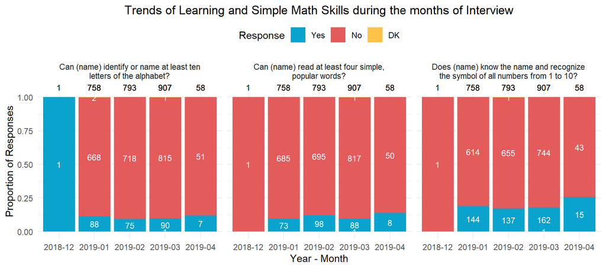

### Physical:

EC9: Can (name) pick up a small object with two fingers, like a stick or a rock from the ground?  
EC10: Is (name) sometimes too sick to play?

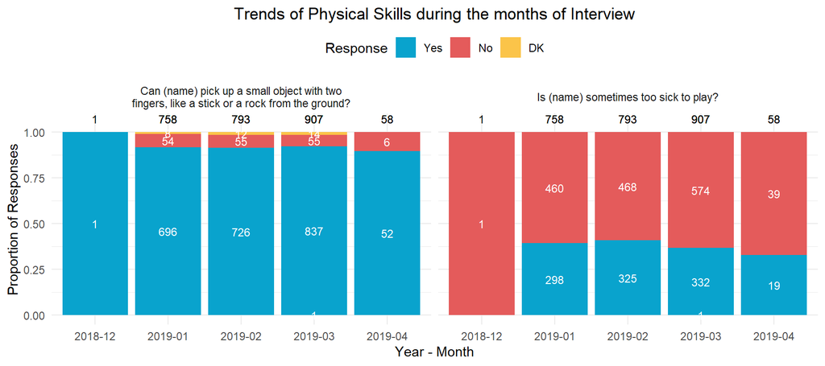

### Learning:

EC11: Does (name) follow simple directions on how to do something correctly?  
EC12: When given something to do, is (name) able to do it independently?

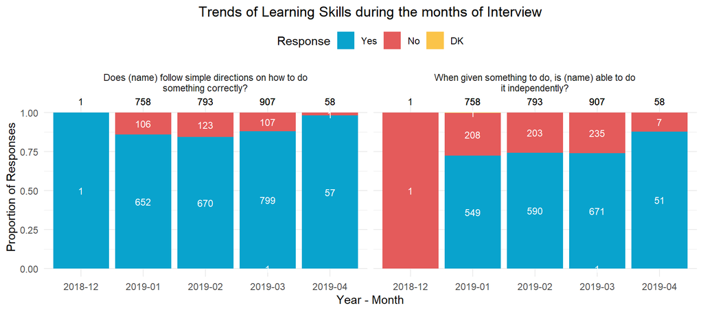

### Socio-emotional:

EC13: Does (name) get along well with other children?  
EC14: Does (name) kick, bite, or hit other children or adults?  
EC15: Does (name) get distracted easily?

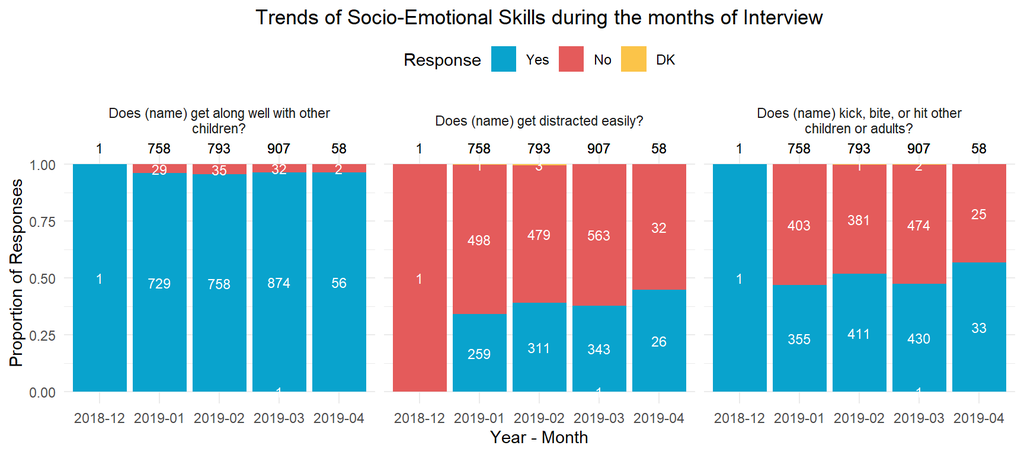

**Thank You**